# Final Project: Support Vector Machines (SVM)

## Introduction

Welcome to this tutorial on support vector machines (SVM)! The SVM algorithm is a powerful and flexible approach to modeling a variety of real-world problems, and we have written this tutorial to give you everything you need to start applying the approach today.

Who are we? We are two graduate students at the School of Data Science at the University of Virginia. Both of us have a strong interest in SVMs and their applications, and we want to share that enthusiasm and knowledge with other students and professionals.

But more importantly, who are *you*? You are probably an undergraduate, graduate, or even a new professional interested in expanding your knowledge of machine learning and data science. You’ve heard of some of the basic approaches, like linear, logistic, and lasso or ridge regression, and you’re familiar with some of the basic concepts, like cross-validation, the types of machine learning problems (classification and regression, etc.), and maybe the bias-variance trade-off. You haven’t seen SVMs before and you’re intrigued, or maybe you’ve tried other tutorials but found your head spinning with mathematical jargon: *Primal problem. Dual problem. Kernel trick. Hilbert space.*

Good news for you! This tutorial has been designed for readers who are more interested in conceptual understanding and practical applications than deep mathematical derivations, and we will focus on developing an intuition for how several varieties of SVM work: by the end of the tutorial, you should be prepared to apply your knowledge to binary classification, multiclass classification, regression, and one-class (novelty detection) problems. The tutorial should be understandable at the Master’s or advanced undergraduate level—but if you want to delve deeper into the theory, this tutorial should equip you with the conceptual understanding to better approach the formal literature.

Throughout the tutorial, we will include conceptual questions and coding demonstrations for you to develop a practical understanding. Although we will include example answers, we encourage you to actually attempt these problems before inspecting the solutions: the best way to develop a practical understanding is to try to apply it, especially when you have the answers available to check your work and learn from your mistakes. This tutorial is built in R, but the approaches learned here will generalize to other languages such as Python. Feel free to follow along in a different programming language of your choosing, but you will need to learn the conventions of different packages from the ones used here. (For Python, we recommend `scikit-learn`.)

## Why should I use SVM?

Before we get started, let’s establish some of the advantages and disadvantages of SVM, relative to other approaches you may have seen—such as generalized linear models (GLMs), lasso/ridge/elastic net regularization, or deep learning. As a data scientist, analyst, or engineer, you should first consider the advantages and the disadvantages of a technique *before* applying it to a problem, rather than the other way around (applying something incorrectly, and finding errors only after wasting your own time and effort).

Depending on your experience, some of this may not make sense immediately—that’s OK! Consider returning to this section after completing the rest of the tutorial, to further cement what you have learned.

### Advantages

- **One method for classification, regression and novelty/outlier detection.** There are not many methods in data science and machine learning that are general enough to handle not only supervised problems with binary class labels, multiple class labels, or quantitative labels, but also unsupervised learning! SVM generalizes to all of these problems.
- **Easily model non-linear class boundaries and relationships, without extensive feature engineering and model selection.** This will sound unremarkable to practitioners of deep learning, but for GLM and lasso/ridge users, SVM opens a wide range of new possibilities. *No method will entirely eliminate your need to do feature engineering*—it’s a key part of the work of any data scientist—but SVM kernels (which will be explained in more detail in a later section) make life much easier. The SVM will easily fit non-linear relationships, in a automatic and data-driven way—rather than an exhaustive, arbitrary, and subjective approach.
- **Balance interpretation with predictive power.** Often, machine learning is visualized on a kind of continuum: a trade-off between simpler, less powerful, but interpretable models on one hand (like linear regression) and highly complicated, state-of-the-art, completely uninterpretable models on the other (like some deep learning). Using this approach, SVMs sit directly in the middle. Using the simplest kernel (linear), you can model very similar relationships to GLMs. Increasing the complexity (and losing interpretability) is then as simple as changing the kernel—a single parameter. Rarely in other techniques do you, the data scientist, have such control over this trade-off. In SVMs, you can simply “flip a switch” from one side to the other, and observe whether you receive enough increased predictive power to justify sacrificing interpretation.
- **SVMs are, quite simply, fast.** SVMs give some of the advantages typical of more complicated models (see above) but at a computational speed more typical of GLM-like methods.
- **Regularization comes “built-in.”** A GLM practitioner may spend a lot of time and effort choosing the best approach to regularize a problem: *should we use the ridge penalty? How about lasso? Do we need something even more general, like elastic net?* SVMs do not have this consideration. Although the hyperparameters still need to be tuned, as in GLMs, it isn’t necessary to “pick” a regularization approach: it’s already a part of SVM. SVMs are especially powerful in contexts where there are far more dimensions than observations, which are intractable for GLMs without regularization. For example, SVMs are frequently used in brain imaging, on datasets with 10,000s of dimensions but only a few hundred observations.

### Diasdvantages

- **SVM just predicts classes, not class probabilities.** If your previous experience is largely with GLMs, Bayesian modeling, and/or deep learning, this may be a surprising distinction, but it is critically important. Most of the previous methods usually provide probabilities of class membership. SVM does **not**. For example,
  - Probabilistic methods: We predict that patient 1 has a 64 percent chance of having the disease.
  - SVM: We predict that patient 1 has the disease. We don’t make any claim about the probability. It may be that your intended use case really needs predicted probabilities—but if that’s the case, SVM should not be the method you use.
- **SVM uses geometry, not statistics.** For data scientists and academics with a more statistics-oriented background, it can be jarring to suddenly lose access to all of the statistial inference a GLM provides: hypothesis tests for the overall model (e.g., $F$-test) and every coefficient (e.g., Wald test) and extensive diagnostic plots to test the model assumptions. SVM is a much more direct optimization problem, and doesn’t make as many assumptions (or produce as many statistical inferences).
- **Depending on your model, you may have more hyperparameters to tune.** The cost of cross-validation, with a grid search, grows exponentially as you have more parameters. If you perform a grid search with 10 possibilities, then with two hyperparameters you have $10^2=100$ possibilities; for three hyperparameters, $10^3 = 1000$, etc. With classification and a linear kernel, you will only have one hyperparameter $C$. But with regression and a RBF kernel, you will have three: $C, \varepsilon, \gamma$. Your cross-validation may become more computationally intensive than a GLM-based approach.

## The Maximium-Margin Classifier

Suppose you are given a set of training observations belonging to one of two classes, each of which is described by some predictor variables we’ll call $X_1$ and $X_2$. You’re then asked to classify a new unknown point based simply on the training points you have before you. How might you go about this? An intuitive or natural start might be to plot the observations in order to see how they’re are clustered visually. Could you draw a line separating both groups? Depending on the side of the line that new point lands on, you should be able to make a more informed decision on how to classify that point. Now how is this accomplished when we have larger dimensions of predictors?

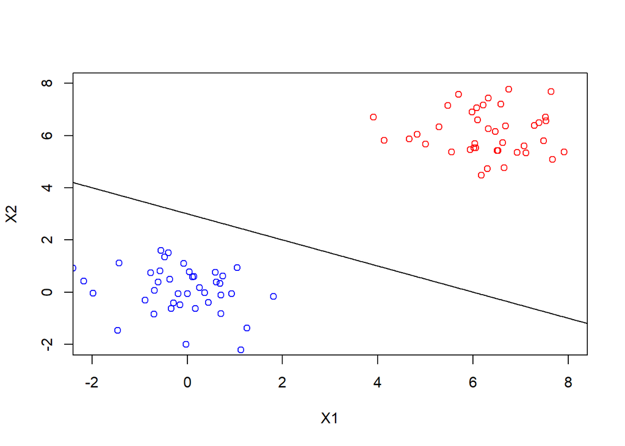

In the most general sense, we just defined a 1-D line that could fully separate our 2-D training data by their target class. If our data was 3-D, we would’ve drawn a 2-D surface. Basically, given $p$ number of predictor variables our goal is to developed a $p-1$ dimensional separator, otherwise known as a hyperplane. Mathematically, this hyperplane can be defined by the equation,

$$\begin{equation}
\beta_0 + \beta_1 X_1 + \beta_2 X_2 + \ldots + \beta_p X_p = 0
\tag{1}
\end{equation}$$

for parameters $\beta_i$ and predictors $X_i$. If an observation with $p$ predictors (which we’ll represent as a $p$ dimensional vector $\textbf{X} = (X_1, X_2, \ldots X_p)^T$) satisfies this equation, the vector will lie on this hyperplane. In our case however, we purposely define a hyperplane so that none of the training observations directly lie on it, and we really only care as to which side of the hyperplane the new test observation lies.

If we are able to fully separate the two classes, then where exactly do we draw our separating hyperplane? There are actually an infinite number of ways we could do this, once you think about all the infinitesimal little translations and rotations that we could apply to the hyperplane.

Before scrolling any further, take a few minutes to consider where *you* would draw the hyperplane on the following data. Why would you choose this one?

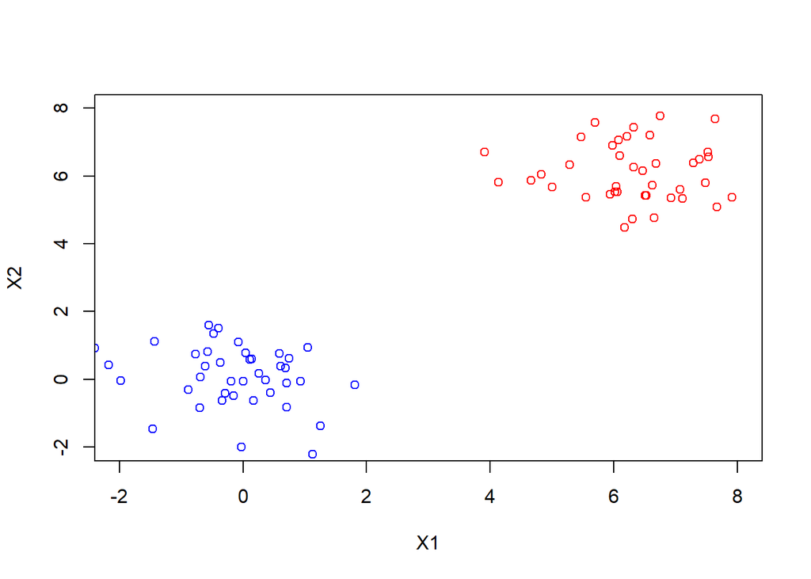

Our best choice is to use the hyperplane that is the farthest away from all the training observations on either side of the plane, otherwise known as the maximum-margin hyperplane. The margin is just the distance between the closest observation and the separator, and we want it to be as large as possible. If we use this hyperplane to decide the target class of our test observations, we call this the **maximum-margin classifier**.

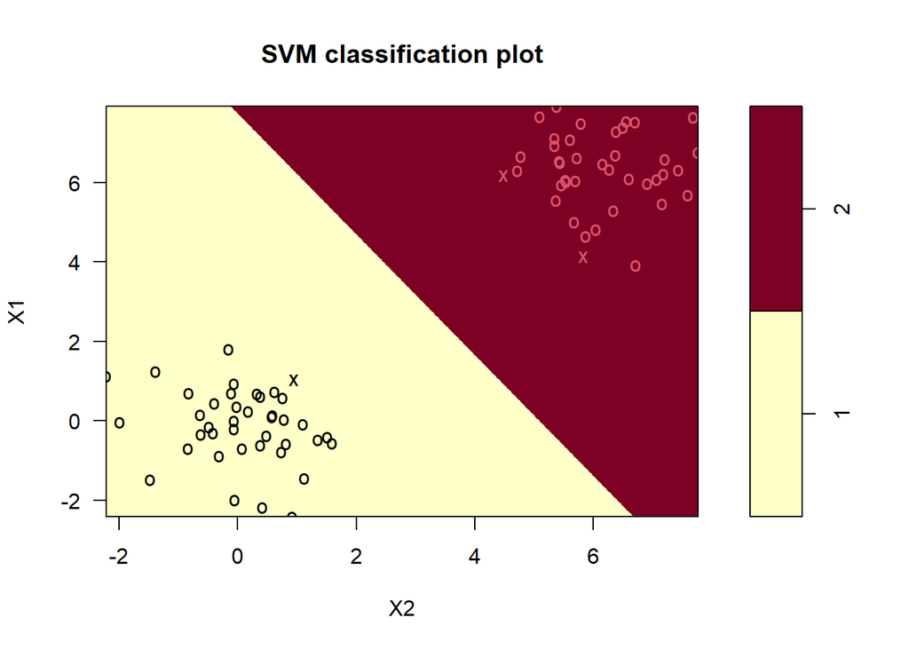

Now step back and think about what it means to classify observations this way. Not only do we care about which side of the hyperplane an observation lies, but if that observation is far from it then we don’t expect it to make a difference where the maximum-margin classifier lies. You might hope that the training and future test observations end up far away from (and on the correct side of) the classifier, otherwise we would have to redefine it—and you’d be right! You might also be thinking about how this applies to data where no separating hyperplane actually exists. Unfortunately, this is where the maximum-margin classifier falls short, but fortunately we have a backup plan for this.

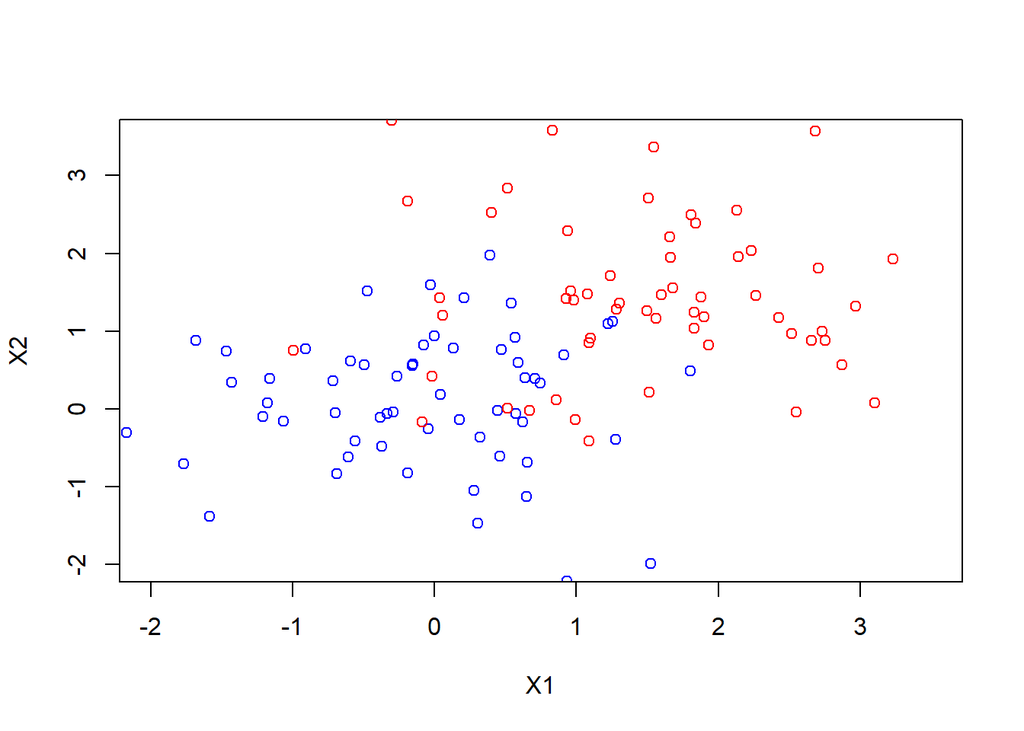

Do we really benefit the most from fully separating our data with complete accuracy, or can we get away with only being right *most* of the time? It turns out the latter is not only possible but it is often more robust than using the maximum-margin classifier. Unlike how we initially showed, we’ll now allow some observations to lie within the margin and sometimes even the incorrect side of the hyperplane. These observations are known as **support vectors**. This is what’s known as using a soft margin,and it leads us to a generalization of the maximum-marginal classifier: **the support vector classifier**.

## Introducing the Hyperparameter, $C$

Ideally, we would like the dataset to be linearly separable, and all of the points to lie outside the margin, on the correct side of the hyperplane. As discussed above, however, that cannot always be the case. Let $\xi_i$ be the degree to which the $i$th point is “on the wrong side.” That is:

1. If the datapoint is outside the margin and correctly classified, $\xi_i=0$.
2. If the datapoint is inside the margin but still correctly classified, $\xi_i$ is the distance from the margin. In this case, $\xi_i$ is still relatively small.
3. If the datapoint is inside the margin and **not** correctly classified, $\xi_i$ is the distance from the *correct* side of the margin—on the other side of the hyperplane. In this case, $\xi_i$ could be quite large.

Observations in cases 2 and 3 are the **support vectors**, vectors where $\xi_i>0$.

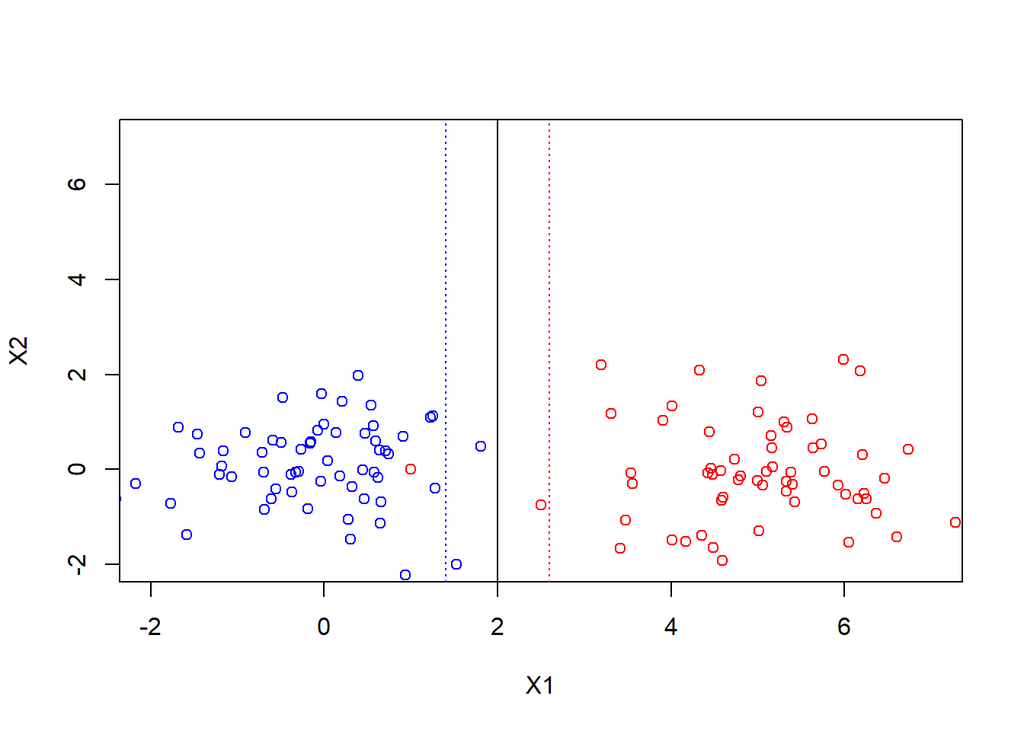

Before proceeding, try to determine how many support vectors there are, of each class in the above graph, and which point has the largest $\xi_i$.

Did you say four (two red, and two blue) support vectors? And the leftmost red point has the largest $\xi_i$? That is correct.

We can then write the following optimization, where $\beta$ are the coefficients of the hyperplane and $\beta_0$ is the intercept, with some $C > 0$:

$$\begin{equation}
\min_{\beta, \beta_0} \left( \frac{1}{2} \|\beta\|^2 + C \sum_{i=1}^N \xi_i \right)
\tag{2}
\end{equation}$$
Since the $\xi_i$ are distances, all $\xi_i \geq 0$.

This is the solution for the support vector machine! Note that the margin $M = \frac{1}{\|\beta\|}$. So SVM trades off between two priorities:

- Maximize the margin for the hyperplane (i.e., minimize $\beta$).
- Minimize the cost associated with all the points contained in that margin.

There is an obvious trade-off here. We could maximize the margin to an enormous value—extending far away from the hyperplane—but then the $\sum \xi_i$ will be enormous, since most points will fall within the margin. We could also minimize $C\sum \xi_i$ to 0 trivially, if we set the margin to 0 (since no points, other than those falling *exactly* on the hyperplane, could be inside it).

Let’s begin with the linearly-separable case again. Imagine you see the following data:

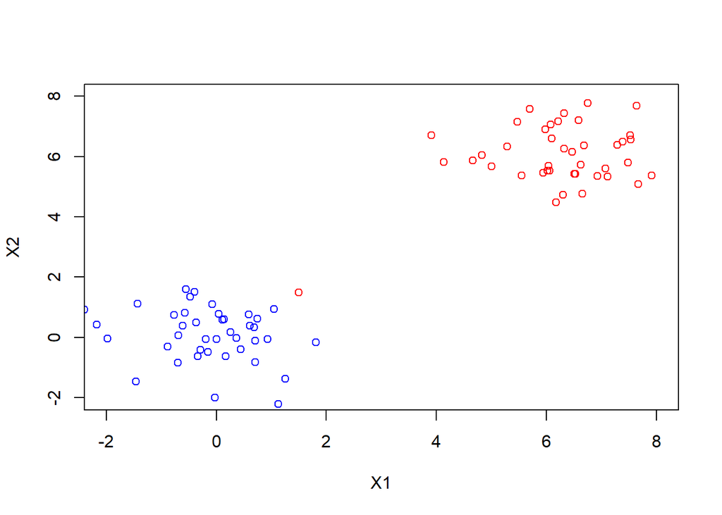

Take a few minutes, before scrolling any further, to consider where you would draw the hyperplane here.

There isn’t one correct answer! Instead, it depends on what value you choose for $C$. Take a second look at Equation 2. You can see that $C$ is the weight applied to the various $\xi_i$, which you can think of as our classifier’s errors. (You may be used to seeing $\epsilon$ used for errors, but epsilon has another meaning in SVM. See the support vector regression section.) So you can think of $C$ as the **cost of misclassifications**.

You may have decided that you wanted to linearly separate the training data, no matter what. After all, that’s all the data you have, so it’s what you should use, right? You might have chosen a hyperplane like this, which corresponds to a very large value of $C$:

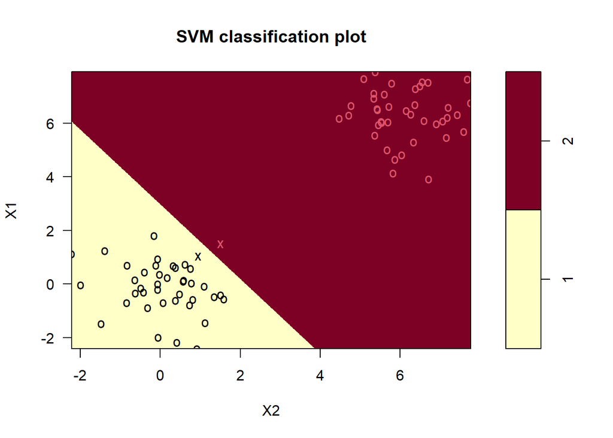

```r
library(e1071)
svm = svm(formula=y ~ ., data=data, cost=1e10, kernel='linear')

plot(svm, data, grid=1e3)
```

Alternatively, you might have chosen to tolerate that strange outlier. The classes otherwise seem quite separable, after all. That point could be an observation error or just a very rare occurence, you may have reasoned, and the true separating hyperplane is probably something like this (a model with smaller $C$):

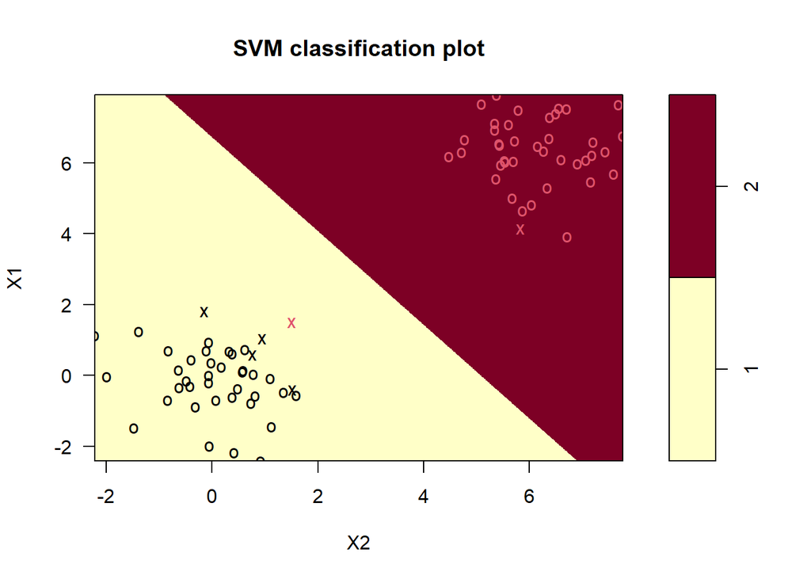

```r
svm = svm(formula=y ~ ., data=data, cost=1, kernel='linear')

plot(svm, data, grid=1e3)
```

Here are a few key concepts to understand:

- **Choosing $C$ to be too large could overfit your training data.** Fitting too closely to your training data, by harshly penalizing any errors on it, could select a hyperplane that doesn’t actually represent the best outcome on your testing data. This becomes especially problematic later in this tutorial, when kernels are introduced and allow you to make nonlinear decision boundaries. As surprising as it may sound, **it may be better to deliberately allow some of your training data to be misclassified**, to build models that generalize better to your testing data.
- **Choosing $C$ to be too small could underfit your training data.** If you chose $C$ to extremely small, there would be little cost to misclassifying anything, and we could pick almost any hyperplane. A similar intuition follows for $C$ values that are small: you will allow too many mistakes.

Take a third look at equation 2, reprinted here for your convenience:

$$\begin{equation}
\min_{\beta, \beta_0} \left( \frac{1}{2} \|\beta\|^2 + C \sum_{i=1}^N \xi_i \right)
\tag{2 revisited}
\end{equation}$$

This leads us to one additional insight: **Large values of $C$ lead to smaller margins; smaller values of $C$ lead to larger margins.** Again, remember the trade-off. If we reduce the second term by a smaller $C$, we increase the first term. Since the margin is $\frac{1}{\| \beta \|}$, this increases the margin.

How can we choose $C$? On very rare occasions, you might be lucky and not have to do so. In brain imaging, for example, there are typically so many dimensions (tens of thousands) compared to observations (hundreds) that it’s very easy for SVM to find a perfectly separating hyperplane. (To see why having more dimensions than observations makes data easily separable, imagine separating only two points in 3D space.) In this field, it’s actually common just to set $C$ arbitrarily large to make sure a separating hyperplane is selected, e.g., $C = 100$.

Usually, however, you won’t be so lucky. Like any hyperparameter in other domains of machine learning (such as $\lambda$ in lasso and ridge penalties), you will probably find $C$ using cross-validation with a grid search. A common approach is to vary along an exponential scale, for example, by testing powers of 2: $2^{-5}, 2^{-4}, \ldots , 2^4, 2^5$. If you absolutely need a default, $C=1$ is a reasonably balanced choice, but as a rule SVM hyperparamters usually need to be tuned. Advanced users might also choose $C$ more efficiently using Bayesian optimization.

## An alternative: Introducing the Hyperparameter, $\nu$

If you read the literature, you may see some authors write this in terms of the training sample size $\ell$ (rather than $N$), the non-intercept coefficients $\mathbf{w}$ (rather than $\beta$), and a negative intercept $\rho = -\beta_0$. You can see clearly that $\sum_{i=1}^N \xi_i$ is no longer multiplied by $C$, but by $\frac{1}{\nu}$: these parameters have a roughly inverse relationship.

Can you guess which one of these models has a larger $\nu$? **Hint**: the support vectors are shown with `X` symbols, and all other points are `O`s.

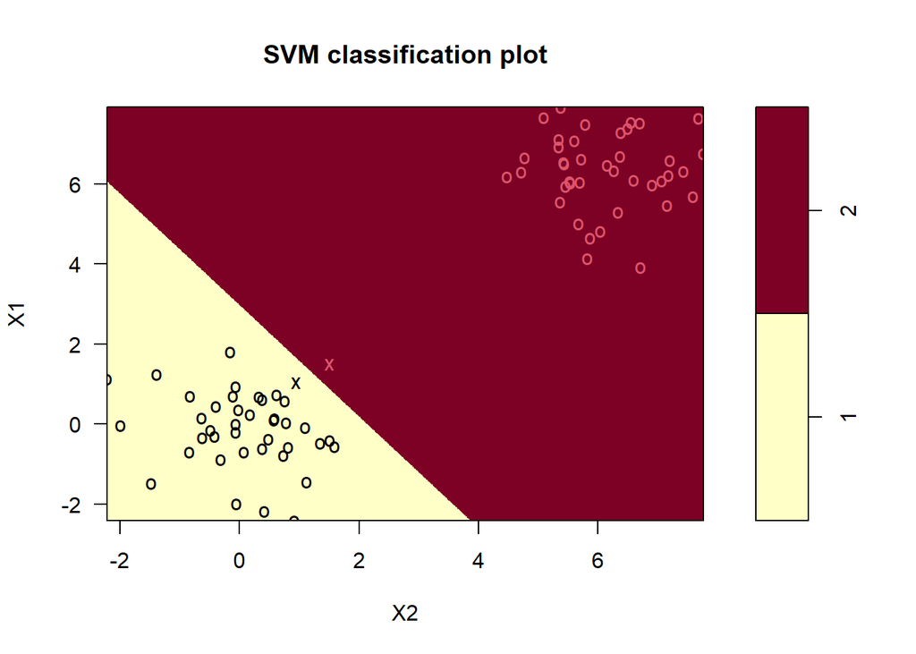

```r
svm = svm(formula=y ~ ., data=data, type='nu-classification', nu=0.001, kernel='linear')

plot(svm, data, grid=1e3)
```

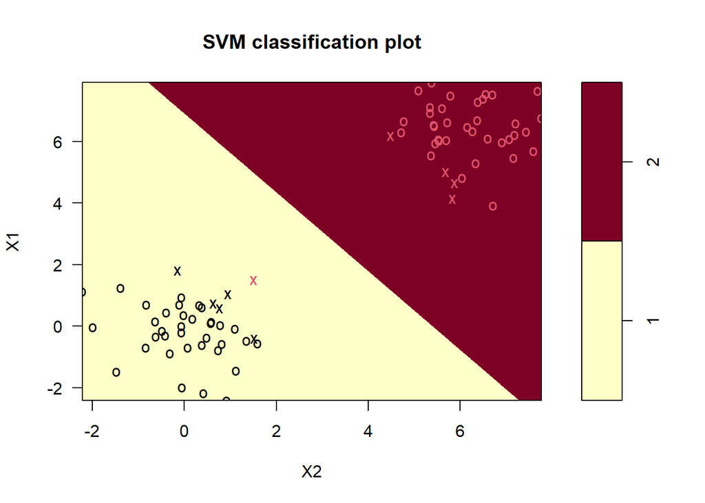

```r
svm = svm(formula=y ~ ., data=data, type='nu-classification', nu=0.1, kernel='linear')

plot(svm, data, grid=1e3)
```

The second plot has many more support vectors, so it’s intuitive that it has a larger $\nu$. It also looks similar to the plot with smaller $C$ from above.

## Introducing the Kernels

So far, we’ve assumed that the best hyperplane to act as our classifier is a linear boundary in our input feature space. In practice, however, we might not expect this assumption to hold in every situation we see. Maybe there is some other enlarged feature space, with more dimensions, in which we could separate the data—for example, we could add quadratic terms for some vectors $x = (a,b)$:

$$\begin{equation*}
(a, b) \rightarrow (a^2, ab, b^2, a, b)
\end{equation*}$$

But as we increase the number of dimensions, mapping our data to this expanded space, calculating distances to the margin (to run the SVM mentioned previously), and mapping the resulting hyperplane back to linear space becomes expensive. In some popular kernels, such as the radial basis function (below), the number of dimensions in the expanded space is actually infinite! How can we possibly calculate a distance in an infinite-dimensional space? The problem seeems computationally intractable.

- Linear (no kernel)
- $n$th-Degree Polynomial: $K(x, x') = (1 + \langle x, x'\rangle)^n$
- Radial Basis Function (RBF): $K(x, x') = \exp(-\gamma ||x - x'||^2)$
- Sigmoid or Neural Network: $K(x, x') = \tanh(\kappa_1 \langle x, x' \rangle + \kappa_2)$

where the inner product of two $p$-vectors $x$ and $x'$ is defined as

$$\begin{equation}
\langle x, x' \rangle = \sum^{p}_{j = 1}x_j x'_j
\tag{4}
\end{equation}$$

To demonstrate these kernels, we’ll use the following data:

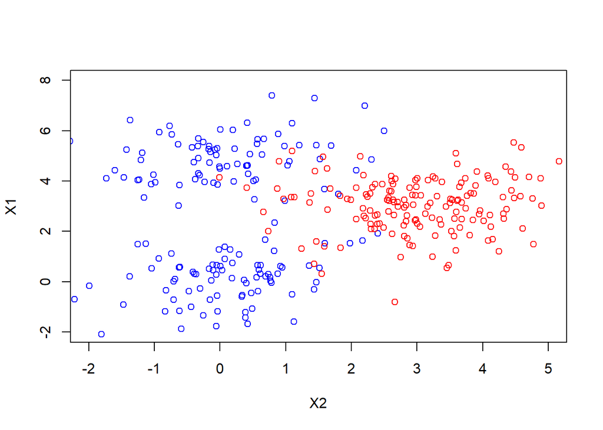

We’ll also formally introduce code for running SVMs in R using the `e1071` library. Here are the four methods you will mainly use:

- `svm` fits a single model.
- `tune.svm` takes similar arguments, but tunes the parameters using cross-validation, bootstrap resampling, or a fixed validation set. You can supply a range of values to tune over, rather than a single value (for example, to select $C$). It returns the best set of hyperparameters.
- `best.svm` combines these two methods. It takes arguments similar to `tune.svm`, but rather than just returning the hyperparameters, runs and returns a model from them.
- `plot.svm` plots the results of a SVM classifier. If you call `plot` with the output from `svm` or `best.svm`, it will call `plot.svm` for automatically.

We will use `best.svm` for simplicity, and tune the hyperparameters using 10-fold cross-validation.

#### Linear

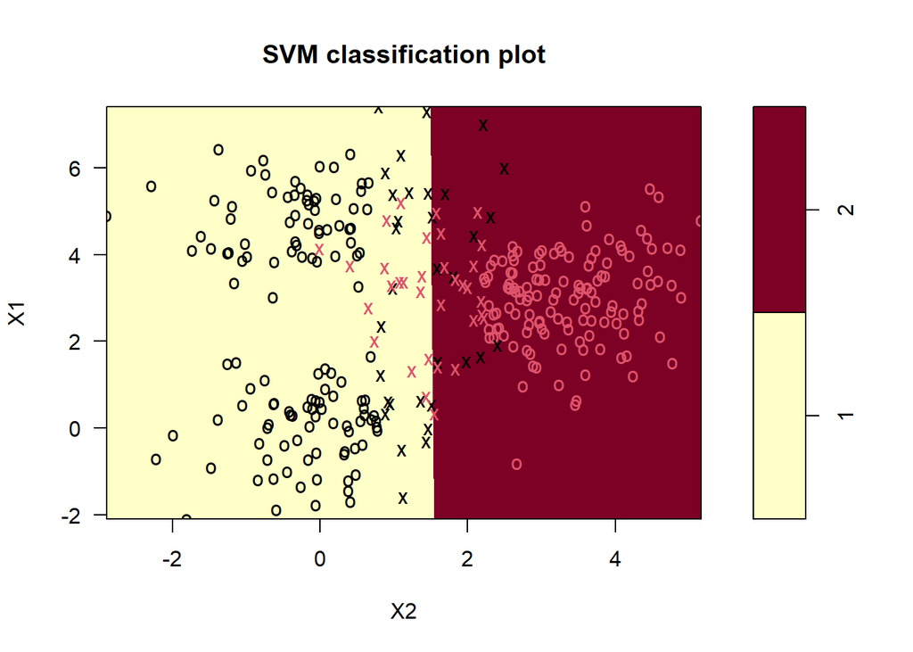

```r
# 2-d representations of the linear kernel
svm = best.svm(y ~ ., data=data, kernel='linear',
               cost = 10^(-5:5),
               tunecontrol = tune.control(sampling='cross', cross=10))
plot(svm, data, grid=1000)
```

#### Polynomial

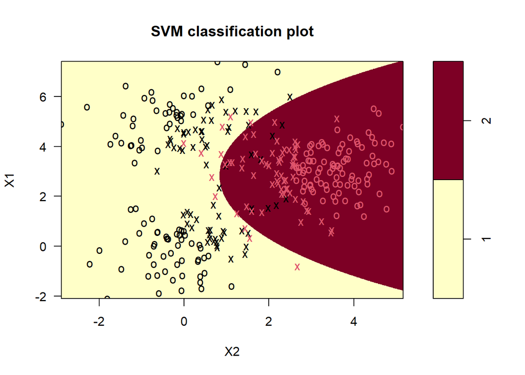

```r
svm = best.svm(y ~ ., data=data, kernel='polynomial',
               cost = 10^(-5:5), degree=2:5, gamma=1, coef0=1,
               tunecontrol = tune.control(sampling='cross', cross=10))
plot(svm, data, grid=1000)
```

#### Radial basis function

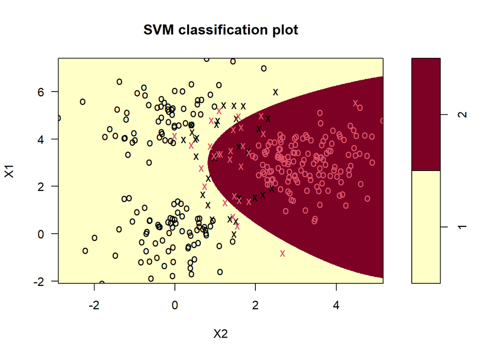

```r
svm = best.svm(y ~ ., data=data, kernel='radial',
               cost = 10^(-3:3), gamma=10^(-5:5),
               tunecontrol = tune.control(sampling='cross', cross=10))
plot(svm, data, grid=1000)
```

#### Sigmoid

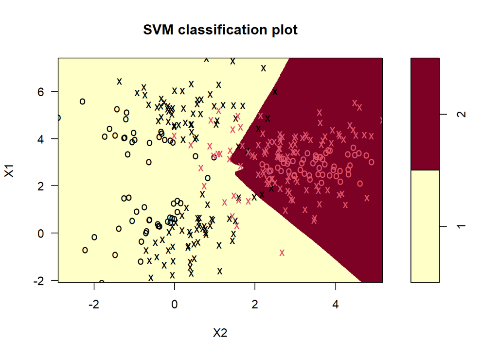

```r
svm = best.svm(y ~ ., data=data, kernel='sigmoid',
               cost = 10^(-3:3), gamma=10^(-5:5), coef0=10^(-5:5),
               tunecontrol = tune.control(sampling='cross', cross=10))
plot(svm, data, grid=1000)
```

In the enlarged space (which we never directly see), the hyperplane is still linear. But when it is mapped back to the original space, it can take on a variety of curved shapes (determined by the choice of kernel). If this seems unintuitive, you have probably already seen this concept, when you fit a simple quadratic curve $y = ax^2 + bx + c$ using linear regression: you created two-dimensional data, $\mathbf{x} = (x, x^2)$, fit the model using multiple linear regression, and then plotted the curve $y = f(x)$ as a function of $x$ alone. The same idea underlies the kernel trick.

The difference now is that we cannot easily map the data into the new space directly—so we rewrite inner products in that space, in terms of the smaller space’s variables. It happens that *this* allows us to write formulas that are tractable, even for some infinite-dimensional enlarged feature spaces.

The effect of the parameter $C$ should be even clearer in these enlarged feature spaces. Previously for the non-separable linear boundary case, large/small values of $C$ decreased/increased the size of our margin. Now, large values of $C$ will lead to tighter fitting boundaries around classes in the original feature space, whereas small values of $C$ will lead to smoother curved boundaries.

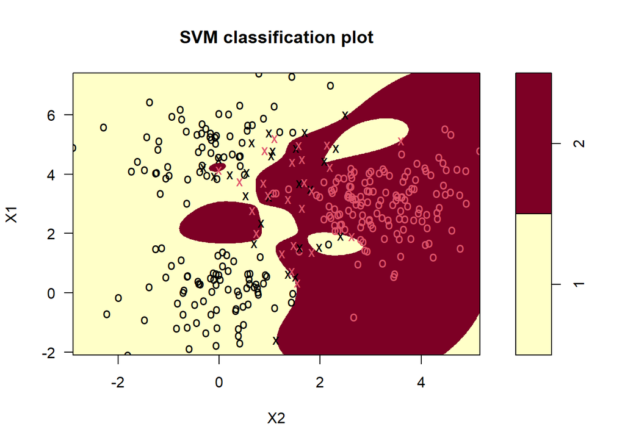

```r
# RBF example to demonstrate the following point
svm = svm(y ~ ., data=data, kernel='radial',
          cost = 1e5, gamma=1)
plot(svm, data, grid=1000)
```

Considerations for choosing kernels:

- You may also have guessed already that the greater flexibility of our hyperplane might carry a risk of overfitting. After all, we are no longer constrained to linear forms—for RBF, we’re not even constrained to forms with a finite number of terms. If you anticipated this, great work! You are correct. Tuning $C$ properly, on unseen data (e.g., using cross-validation), is now even more important. Above, see an example of a badly-overfit model using the RBF kernel and a very large $C = 10^5$.
- Choosing increasingly complex kernels sacrifices the interpretation of the model coefficients. For RBF, you cannot even write them out any more! However, RBF is highly flexible and often achieves high accuracy. When choosing a kernel, feel free to try multiple options for accuracy, and consider whether (for your particular problem) sacrificing interpretability is worth it.
- Note that many kernels have hyperparameters you will have to tune, in addition to $C$. In the above definitions, the polynomial kernel has a degree; the RBF kernel has a hyperparameter $\gamma$. Some authors parameterize these kernels with *even more* hyperparameters; for example, in the R package `e1071`, the polynomial kernel is more general and has 3 hyperparameters $\gamma, c_0, d$: $K(x, x') = (c_0 + \gamma \langle x, x'\rangle)^d$. The above definition was the special case where $\gamma = c_0 = 1$.

In summary, the advantage of using kernel functions that we won’t have to actually compute the coordinates of our input data in the kernel’s higher-dimensional *implicit* feature space. Instead, it is possible for us just to compute what the inner products of all pairs of our data *would be* in the higher-dimensional space, which can be computationally more feasible. By using these higher-dimensional feature spaces, we can fit many different non-linear relationships while still using SVM just as before.

## Multiclass-classification

Up until now, we’ve only used SVMs to solve binary classification. Luckily, there have been many different proposals to extend the use of SVMs into multi-classification problems. We will briefly present two simple and popular approaches here:

- **One-versus-All** classification: In the case of $K > 2$ target classes, we will create $K$ different SVMs where each time our goal is to classify whether a given observation is in the $K$th class, or any of the rest. This can be implemented by coding the $K$th response variable as +1 and the other responses as -1. For a given test observation $\boldsymbol{X}$, whichever $K$th SVM results in the highest value of $\beta_{0k} + \boldsymbol{X}^T \boldsymbol{\beta_k}$, the observation will be assigned to that corresponding class. One can imagine the larger this value, the higher confidence we have in that test observation belonging to that class since it lies the farthest away from the classifier (on the correct side of the margin).

For example, we might train (with four classes) the following classifiers:

| Classifiers | 1 vs 2,3,4 | 2 vs 1,3,4 | 3 vs 1,2,4 | 4 vs 1,2,3 |
| --- | --- | --- | --- | --- |
| $\beta_{0k} + \boldsymbol{X}^T \boldsymbol{\beta_k}$ | 0.5 | 1.2 | 1.4 | 0.3 |

So we select class 3 as the prediction.

- **One-versus-One** classification: In the case of $K > 2$ target classes, we will create $\binom{K}{2} = \frac{K(K-1)}{2}$ different SVMs where each SVM compares a different pair of classes. We then classify a test obsevation for each of the $\binom{K}{2}$ SVMs and tally the number of times that observation is assigned to each class. As one might expect, the class that the observation was assigned to most frequently is how we will decide how to classify the observation.

For example, we might train (with four classes) the following classifiers:

|  | Classifiers |  |  | Votes |  |
| --- | --- | --- | --- | --- | --- |
| 1 vs 2 | 1 vs 3 | 1 vs 4 | 1 | 1 | 4 |
|  | 2 vs 3 | 2 vs 4 |  | 3 | 4 |
|  |  | 3 vs 4 |  |  | 4 |

So 4 receives the most “votes,” and we select 4 as the prediction.

Here’s a demo of multiclass classification with the R package `e1071`, using a classic problem in machine learning, the Iris dataset. Note that behind the scenes, the **One-versus-One** approach is used.

```r
# Load Iris data
data(iris)
head(iris)
```

```
##   Sepal.Length Sepal.Width Petal.Length Petal.Width Species
## 1          5.1         3.5          1.4         0.2  setosa
## 2          4.9         3.0          1.4         0.2  setosa
## 3          4.7         3.2          1.3         0.2  setosa
## 4          4.6         3.1          1.5         0.2  setosa
## 5          5.0         3.6          1.4         0.2  setosa
## 6          5.4         3.9          1.7         0.4  setosa
```

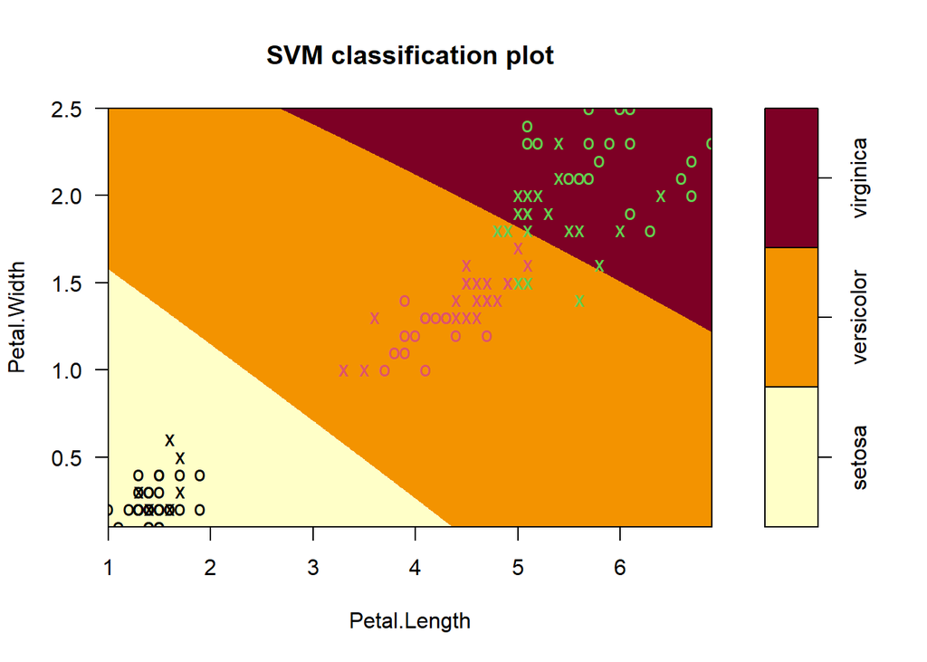

```r
# Size of data
n <- nrow(iris)

# Proportion of data separated into training and test sets
train_size = .75

# Randomly choose training data indices, set seed for reproducibility
set.seed(1)
ind <- sample(n, round(train_size*n))
train <- iris[ind,]
test <- iris[-ind,]

# Train the SVM
svm_iris <- best.svm(Species~.,
                 data = train,
                 type='C-classification',
                 kernel='radial',  # Use RBF kernel
                 gamma=10^(-5:5), cost=10^(-5:5),  # Tune the parameters
                 tunecontrol = tune.control(sampling='cross', cross=10))

# Plot the trained classification Petal.Width vs Length where Sepal.Width & Length are 3 & 5 respectively
plot(svm_iris, train, Petal.Width ~ Petal.Length,
     slice=list(Sepal.Width=3, Sepal.Length=5), grid=1000)
```

```r
# Predict on the test set with trained SVM
prediction <- predict(svm_iris, test)

# Show confusion matrix of our predictions
conf_mat <- table(test$Species, prediction)
conf_mat
```

```
##             prediction
##              setosa versicolor virginica
##   setosa         13          0         0
##   versicolor      0         14         0
##   virginica       0          1        10
```

```r
# Accuracy of our predictions
sum(diag(conf_mat))/nrow(test)
```

```
## [1] 0.9736842
```

## Support Vector Regression (SVR)

We will now show how the support vector approach generalizes beyond just classification problems, starting with regression. Now, our labels are not binary classes, but instead real-valued.

Instead of trying to maximize the margin on our hyperplane (dividing two classes), our hyperplane will attempt to fit to the data, just in a typical regression problem. We define another hyperparameter $\varepsilon$, the width of a “$\varepsilon$-tube” around our hyperplane. It closely resembles the margin from the previous approach, but instead of separating two classes, it’s the bounds of our hyperplane’s prediction.

In this approach, we define two different types of “errors,”, $\xi_i$ and $\xi^*_i$. Each observation $x_i$ falls into one of three categories. Let $y_i$ be the actual label, and $\hat{y}_i$ the SVR prediction.

- The point $x_i$ falls **inside** the $\varepsilon$-tube (black points): $\hat{y}_i-\varepsilon \leq y_i \leq \hat{y}_i+\varepsilon$. Here, we consider there to be no prediction error: $\xi_i = \xi^*_i = 0$.
- The point $x_i$ falls **above** the $\varepsilon$-tube (blue points): $y_i \geq \hat{y}_i+\varepsilon$. Here, there is an error, which we represent in $\xi_i$, the amount by which the true point falls above the $\varepsilon$-tube.
- The point $x_i$ falls **below** the $\varepsilon$-tube (red points): $y_i \leq \hat{y}_i-\varepsilon$. Here, there is a different type of error, which we represent in $\xi^*_i$, the amount by which the true point falls below the $\varepsilon$-tube.

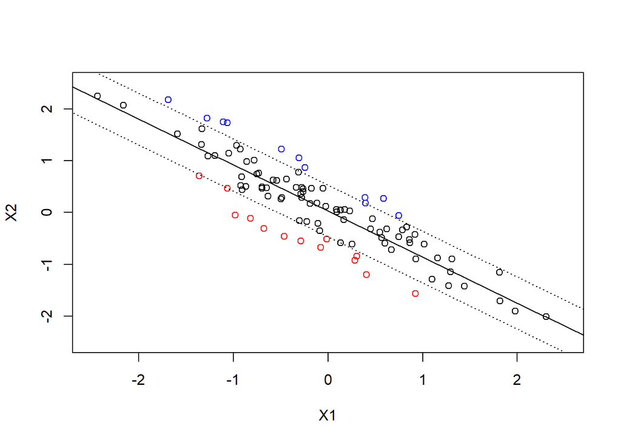

Already, you may see the conceptual basis of $C$ and $\varepsilon$ emerging. $\varepsilon$ represents a kind of tolerance for errors: if the prediction is wrong by $\varepsilon$ or less, then we apply no cost/penalty for this observation. (Note that SVMs scale both the $x$ and $y$ to mean 0 and unit variance, so $\varepsilon=0.1$, for example, means the same thing for any SVR problem.) If we *do* apply a penalty, however, because the point falls outside the $\varepsilon$-tube, then $C$ controls how much penalty we apply. Note also that $\xi_i$ and $\xi^*_i$ are never negative, and at least one of them is always 0 (both are 0 only for points inside the tube).

We can then set up the optimization for this problem

$$\begin{equation}
\min_{\beta, \beta_0} \left( \frac{1}{2} \|\beta\|^2 + C \sum_{i=1}^N (\xi_i + \xi^*_i) \right)
\label{5}
\end{equation}$$

Does this look familiar? Once you understand the $\varepsilon$-tube, and what it means for $\xi_i$ and $\xi^*_i$, the optimization problem is almost the exact same as support vector classification! The first term is identical, and the second changes only to add our new type of error term: it’s still a penalty, weighted by $C$, for the size of our model’s mistakes.

This approach is especially powerful when you combine it with what you’ve already learned about kernels. Every student in data science and statistics has had the experience of frustratingly trying to find the best non-linear transformations to model a messy non-linear relationship. For example, consider a very difficult problem like this one:

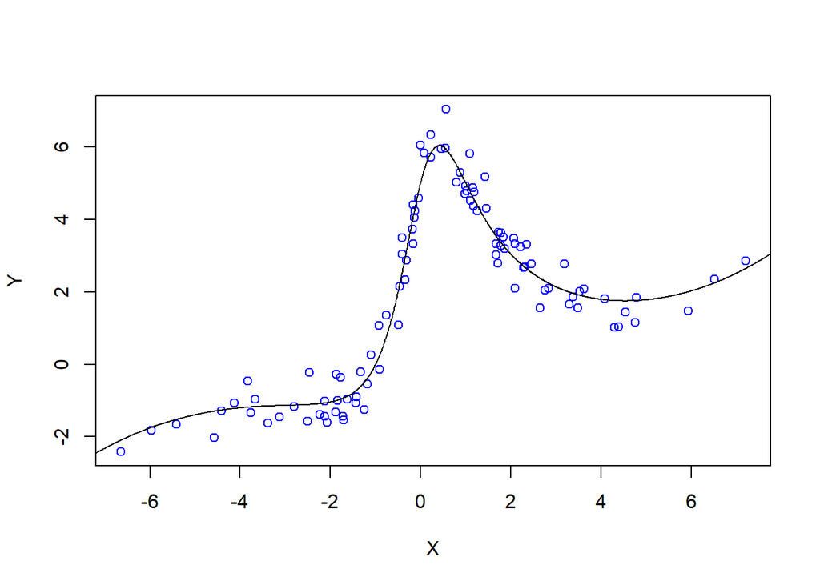

The true relationship, plotted in black, is
$$\begin{equation*}
E[y \mid X = x] = 5 \frac{1+x}{1+x^2} + 0.005x^3
\end{equation*}$$
One hundred points are sampled from this relationship, with a random error term of $\mathcal{N}(0, 0.5)$ added to every $y$-value (blue). This kind of problem would be exceedingly difficult with an ordinary GLM if you didn’t know the data-generating mechanism (given above). What kind of features could you possibly engineer for this?

With the kernel trick, we don’t need to worry about this. Below, we demonstrate how easily the RBF kernel can fit to this problem.

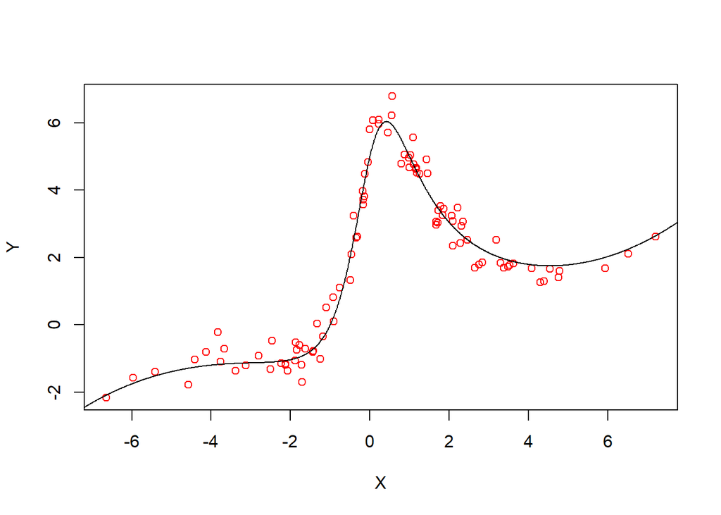

```r
svm = svm(Y ~ X, data=data, kernel='radial',
          cost = 1e3, epsilon=0.1, gamma=1e3,
          tunecontrol = tune.control(sampling='cross', cross=10))

# We have to plot the data ourselves, since plot.svm only handles classification problems.
yhat = fitted.values(svm)
plot(X, yhat, col='red', xlab="X", ylab="Y", type='p')
lines(support, f(support), col='black')
```

Using the kernel trick, our predictions (red) fit remarkably well—and we didn’t even have to do any feature engineering!

(Note that `svm`, `tune.svm`, and `best.svm` automatically detect that our $y$-variable is continuous, rather than a discrete factor. These methods will default to classifiation or regression (with $C$) based on the $y$-variable you provide. You can also specify it manually (or to use $\nu$ rather than $C$) using the optional `type` argument.)

## One-class SVM

At this point, you should be well acquainted with the typical pattern of SVM classification. Based on our training from both types of target classes, we can develop a model that can detect both types of classes within a set of test observations. Now consider the following example:

You are given a list of foods that someone enjoys. The list also contains information about each food’s corresponding recipe/ingredients. You’re then asked to recommend different types of foods that you think they might also enjoy. In other words, just find foods that you know are similar to the accepted ones. However, we also know that this person is a particular person is a picky eater, so we want to be careful not to recommend foods that they won’t enjoy. Do you think perhaps we could use SVMs to do the job?

There’s one fundamental difference to this scenario and the one that we’ve presented to you throughout this tutorial: Here, our training set is *only* comprised of observations of the positive class. It turns out, this constraint makes it harder for us to identify representative negative examples. This scenario is what’s known as **novelty detection**, where our training set is not polluted with by outliers and we are interested in detecting new observations that are outliers.

We can actually use a very similar optimization to what we used for $\nu$-SVM! Here’s the optimization:

$$\begin{equation}
\min_{\beta, \beta_0} \left( \frac{1}{2} \|\beta\|^2 + \frac{1}{\nu N} \sum_{i=1}^N \xi_i + \beta_0 \right)
\tag{6}
\end{equation}$$

Rather than $C$, one-class SVM uses $\nu \in [0, 1]$. As in $\nu$-SVM, $\nu$ is a lower bound on the proportion of points that are **support vectors**. If $\nu$ approaches 0, it’s a hard-margin classifier (we won’t have any vectors within the margin). Increasing $\nu$ allows a softer approach.

Here’s a demo of one-class classification, using the `banana` dataset from the `imbalance` library:

```r
library(imbalance)
data("banana")

# Show the imbalance in the classes
summary(banana$Class)
```

```
## negative positive
##     2376      264
```

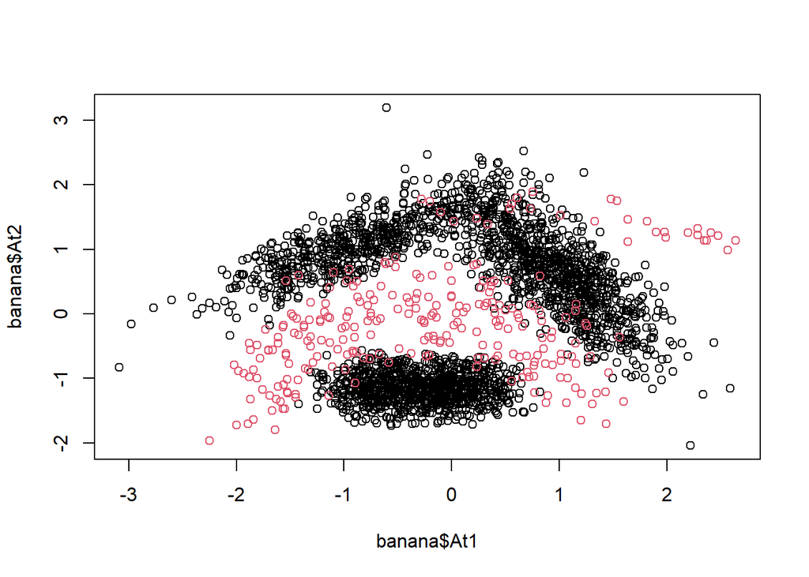

```r
plot(banana$At1, banana$At2, col=banana$Class)
```

```r
# Choose only one of the classes
df <- subset(banana, Class == "positive")
x <- subset(df, select = -Class) # Make x training variables
y <- df$Class # Make y training variable(dependent)
model <- svm(x,
             type='one-classification',
             kernel = "radial",
             gamma= .01, nu=.9) # Train an one-classification

# create predictions
prediction <- predict(model,subset(banana, select=-Class))

# Show confusion matrix of our predictions
conf_mat <- table(banana$Class, prediction)
conf_mat
```

```
##           prediction
##            FALSE TRUE
##   negative  2376    0
##   positive   237   27
```

```r
# Accuracy of our predictions
sum(diag(conf_mat))/nrow(banana)
```

```
## [1] 0.9102273
```

## Conclusion

Congratulations! You have reached the end of the tutorial. You know have a good understanding of support vector machines, in all of its various parameterizations and contexts. You’ve seen enough code to begin applying the approach yourself in R, and the documentation for `e1071` will help you the rest of the way. More importantly, though, you’ve developed a conceptual understanding that will accompany you to other packages and programming languages, like Python or Matlab.

We hope you have enjoyed the tutorial!

## References

[1]P.-H. Chen, C.-J. Lin, and B. Schölkopf, “A tutorial on ν-support vector machines,” Appl. Stochastic Models Bus. Ind., vol. 21, no. 2, pp. 111–136, Mar. 2005.

[2]I. Cordón, S. García, A. Fernández, and F. Herrera, imbalance: Preprocessing Algorithms for Imbalanced Datasets. 2018.

[3]H. Drucker, C. J. C. Burges, L. Kaufman, A. J. Smola, and V. Vapnik, “Support Vector Regression Machines,” in Advances in Neural Information Processing Systems 9, M. C. Mozer, M. I. Jordan, and T. Petsche, Eds. MIT Press, 1997, pp. 155–161.

[4]T. Hastie, R. Tibshirani, and J. Friedman, Elements of Statistical Learning, Second. Stanford: Springer, 2008.

[5]G. James, D. Witten, T. Hastie, and R. Tibshirani, Eds., An introduction to statistical learning: with applications in R. New York: Springer, 2013.

[6]S. LaConte, S. Strother, V. Cherkassky, J. Anderson, and X. Hu, “Support vector machines for temporal classification of block design fMRI data,” NeuroImage, vol. 26, no. 2, pp. 317–329, Jun. 2005.

[7]L. M. Manevitz and M. Yousef, “One-Class SVMs for Document Classiﬁcation,” Journal of Machine Learning Research, pp. 139–154, 2001.

[8]D. Meyer et al., e1071: Misc Functions of the Department of Statistics, Probability Theory Group (Formerly: E1071), TU Wien. 2019.

[9]B. Schölkopf, J. C. Platt, J. Shawe-Taylor, A. J. Smola, and R. C. Williamson, “Estimating the Support of a High-Dimensional Distribution,” Neural Computation, vol. 13, p. 2001, 1999.

[10]A. J. Smola and B. Schölkopf, “A tutorial on support vector regression,” Statistics and Computing, vol. 14, no. 3, pp. 199–222, Aug. 2004.